# Project: Investigate No-show appointments Dataset.

- Introduction
- Data Wrangling
- Exploratory Data Analysis
- Conclusions

## Introduction

> - This dataset collects information from 100k medical appointments in Brazil and is focused on the question of whether or not patients show up for their appointment. A number of characteristics about the patient are included in each row. I will try by data which are available to answer that question:
> - #### "What may affect the patient's attendance of the appointment?".

```python
import pandas as pd
import numpy as np
import matplotlib.pyplot as plt
import seaborn as sns

%matplotlib inline
from datetime import datetime
```

## Data Wrangling

### General Properties

```python
df=pd.read_csv(r'F:\Profissional Track Second Project\investigate-a-dataset-template.ipynb\noshowappointments-kagglev2-may-2016.csv')
df.head()
```

|  | PatientId | AppointmentID | Gender | ScheduledDay | AppointmentDay | Age | Neighbourhood | Scholarship | Hipertension | Diabetes | Alcoholism | Handcap | SMS_received | No-show |
| --- | --- | --- | --- | --- | --- | --- | --- | --- | --- | --- | --- | --- | --- | --- |
| 0 | 2.987250e+13 | 5642903 | F | 2016-04-29T18:38:08Z | 2016-04-29T00:00:00Z | 62 | JARDIM DA PENHA | 0 | 1 | 0 | 0 | 0 | 0 | No |
| 1 | 5.589978e+14 | 5642503 | M | 2016-04-29T16:08:27Z | 2016-04-29T00:00:00Z | 56 | JARDIM DA PENHA | 0 | 0 | 0 | 0 | 0 | 0 | No |
| 2 | 4.262962e+12 | 5642549 | F | 2016-04-29T16:19:04Z | 2016-04-29T00:00:00Z | 62 | MATA DA PRAIA | 0 | 0 | 0 | 0 | 0 | 0 | No |
| 3 | 8.679512e+11 | 5642828 | F | 2016-04-29T17:29:31Z | 2016-04-29T00:00:00Z | 8 | PONTAL DE CAMBURI | 0 | 0 | 0 | 0 | 0 | 0 | No |
| 4 | 8.841186e+12 | 5642494 | F | 2016-04-29T16:07:23Z | 2016-04-29T00:00:00Z | 56 | JARDIM DA PENHA | 0 | 1 | 1 | 0 | 0 | 0 | No |

### Dataset volume:

```python
df.shape
```

```
(110527, 14)
```

##### * This dataset has 110527 rows and 14 columns.

### Check if we have a duplicated entries:

```python
df.duplicated().sum()
```

```
0
```

##### * No duplicated entries in the dataset.

### View the general information of the dataset:

```python
df.info()
```

```
<class 'pandas.core.frame.DataFrame'>
RangeIndex: 110527 entries, 0 to 110526
Data columns (total 14 columns):
 #   Column          Non-Null Count   Dtype
---  ------          --------------   -----
 0   PatientId       110527 non-null  float64
 1   AppointmentID   110527 non-null  int64
 2   Gender          110527 non-null  object
 3   ScheduledDay    110527 non-null  object
 4   AppointmentDay  110527 non-null  object
 5   Age             110527 non-null  int64
 6   Neighbourhood   110527 non-null  object
 7   Scholarship     110527 non-null  int64
 8   Hipertension    110527 non-null  int64
 9   Diabetes        110527 non-null  int64
 10  Alcoholism      110527 non-null  int64
 11  Handcap         110527 non-null  int64
 12  SMS_received    110527 non-null  int64
 13  No-show         110527 non-null  object
dtypes: float64(1), int64(8), object(5)
memory usage: 11.8+ MB
```

##### * The dataset is completely entery there is no empty data, we see here data type for each column.

### View basic statistical details:

```python
df.describe()
```

|  | PatientId | AppointmentID | Age | Scholarship | Hipertension | Diabetes | Alcoholism | Handcap | SMS_received |
| --- | --- | --- | --- | --- | --- | --- | --- | --- | --- |
| count | 1.105270e+05 | 1.105270e+05 | 110527.000000 | 110527.000000 | 110527.000000 | 110527.000000 | 110527.000000 | 110527.000000 | 110527.000000 |
| mean | 1.474963e+14 | 5.675305e+06 | 37.088874 | 0.098266 | 0.197246 | 0.071865 | 0.030400 | 0.022248 | 0.321026 |
| std | 2.560949e+14 | 7.129575e+04 | 23.110205 | 0.297675 | 0.397921 | 0.258265 | 0.171686 | 0.161543 | 0.466873 |
| min | 3.921784e+04 | 5.030230e+06 | -1.000000 | 0.000000 | 0.000000 | 0.000000 | 0.000000 | 0.000000 | 0.000000 |
| 25% | 4.172614e+12 | 5.640286e+06 | 18.000000 | 0.000000 | 0.000000 | 0.000000 | 0.000000 | 0.000000 | 0.000000 |
| 50% | 3.173184e+13 | 5.680573e+06 | 37.000000 | 0.000000 | 0.000000 | 0.000000 | 0.000000 | 0.000000 | 0.000000 |
| 75% | 9.439172e+13 | 5.725524e+06 | 55.000000 | 0.000000 | 0.000000 | 0.000000 | 0.000000 | 0.000000 | 1.000000 |
| max | 9.999816e+14 | 5.790484e+06 | 115.000000 | 1.000000 | 1.000000 | 1.000000 | 1.000000 | 4.000000 | 1.000000 |

#### Here we have a numeric values only in 'Age' column so we can view as below:

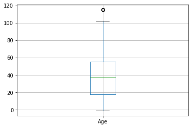

```python
df.Age.describe()
df.boxplot(column=['Age']);
```

##### * As we see the average of age for Patients is 37 years and it is also the median of data age,

##### minimum age is (-1) year?,

##### maximum age is 115 years,

##### Age 18 y/o has 25% from Patients volume,

##### Age 55 y/o has 75% from Patients volume,

##### standard deviation for Age is 23 year.

###### * This entry is incorrect that Age value is -1

```python
df[df.isin({-1}).any(1)]
```

|  | PatientId | AppointmentID | Gender | ScheduledDay | AppointmentDay | Age | Neighbourhood | Scholarship | Hipertension | Diabetes | Alcoholism | Handcap | SMS_received | No-show |
| --- | --- | --- | --- | --- | --- | --- | --- | --- | --- | --- | --- | --- | --- | --- |
| 99832 | 4.659432e+14 | 5775010 | F | 2016-06-06T08:58:13Z | 2016-06-06T00:00:00Z | -1 | ROMÃO | 0 | 0 | 0 | 0 | 0 | 0 | No |

### Adding a column 'Day_of_Schedule' for show day of week for 'ScheduledDay',

### and a column 'Day_of_Appointment' for show day of week for 'Appointment Day':

### to see if no show cases are occur on a specific day or days during the week?

```python
f = lambda x: datetime.strptime(x, '%Y-%m-%dT%H:%M:%SZ')
df.ScheduledDay = df.ScheduledDay.apply(f)
df.AppointmentDay = df.AppointmentDay.apply(f)
```

```python
df['Day_of_Schedule']=df['ScheduledDay'].dt.day_name()
df['Day_of_Appointment']=df['AppointmentDay'].dt.day_name()
df.head()
```

|  | PatientId | AppointmentID | Gender | ScheduledDay | AppointmentDay | Age | Neighbourhood | Scholarship | Hipertension | Diabetes | Alcoholism | Handcap | SMS_received | No-show | Day_of_Schedule | Day_of_Appointment |
| --- | --- | --- | --- | --- | --- | --- | --- | --- | --- | --- | --- | --- | --- | --- | --- | --- |
| 0 | 2.987250e+13 | 5642903 | F | 2016-04-29 18:38:08 | 2016-04-29 | 62 | JARDIM DA PENHA | 0 | 1 | 0 | 0 | 0 | 0 | No | Friday | Friday |
| 1 | 5.589978e+14 | 5642503 | M | 2016-04-29 16:08:27 | 2016-04-29 | 56 | JARDIM DA PENHA | 0 | 0 | 0 | 0 | 0 | 0 | No | Friday | Friday |
| 2 | 4.262962e+12 | 5642549 | F | 2016-04-29 16:19:04 | 2016-04-29 | 62 | MATA DA PRAIA | 0 | 0 | 0 | 0 | 0 | 0 | No | Friday | Friday |
| 3 | 8.679512e+11 | 5642828 | F | 2016-04-29 17:29:31 | 2016-04-29 | 8 | PONTAL DE CAMBURI | 0 | 0 | 0 | 0 | 0 | 0 | No | Friday | Friday |
| 4 | 8.841186e+12 | 5642494 | F | 2016-04-29 16:07:23 | 2016-04-29 | 56 | JARDIM DA PENHA | 0 | 1 | 1 | 0 | 0 | 0 | No | Friday | Friday |

```python
df.info()
```

```
<class 'pandas.core.frame.DataFrame'>
RangeIndex: 110527 entries, 0 to 110526
Data columns (total 16 columns):
 #   Column              Non-Null Count   Dtype
---  ------              --------------   -----
 0   PatientId           110527 non-null  float64
 1   AppointmentID       110527 non-null  int64
 2   Gender              110527 non-null  object
 3   ScheduledDay        110527 non-null  datetime64[ns]
 4   AppointmentDay      110527 non-null  datetime64[ns]
 5   Age                 110527 non-null  int64
 6   Neighbourhood       110527 non-null  object
 7   Scholarship         110527 non-null  int64
 8   Hipertension        110527 non-null  int64
 9   Diabetes            110527 non-null  int64
 10  Alcoholism          110527 non-null  int64
 11  Handcap             110527 non-null  int64
 12  SMS_received        110527 non-null  int64
 13  No-show             110527 non-null  object
 14  Day_of_Schedule     110527 non-null  object
 15  Day_of_Appointment  110527 non-null  object
dtypes: datetime64[ns](2), float64(1), int64(8), object(5)
memory usage: 13.5+ MB
```

### Data Cleaning:

### Now i will delete 'PatientId' and 'AppointmentID' columns as i will not need it.

```python
# After discussing the structure of the data and any problems that need to be
#   cleaned, perform those cleaning steps in the second part of this section.
df.drop(['PatientId','AppointmentID'],axis=1,inplace=True)
df.head()
```

|  | Gender | ScheduledDay | AppointmentDay | Age | Neighbourhood | Scholarship | Hipertension | Diabetes | Alcoholism | Handcap | SMS_received | No-show | Day_of_Schedule | Day_of_Appointment |
| --- | --- | --- | --- | --- | --- | --- | --- | --- | --- | --- | --- | --- | --- | --- |
| 0 | F | 2016-04-29 18:38:08 | 2016-04-29 | 62 | JARDIM DA PENHA | 0 | 1 | 0 | 0 | 0 | 0 | No | Friday | Friday |
| 1 | M | 2016-04-29 16:08:27 | 2016-04-29 | 56 | JARDIM DA PENHA | 0 | 0 | 0 | 0 | 0 | 0 | No | Friday | Friday |
| 2 | F | 2016-04-29 16:19:04 | 2016-04-29 | 62 | MATA DA PRAIA | 0 | 0 | 0 | 0 | 0 | 0 | No | Friday | Friday |
| 3 | F | 2016-04-29 17:29:31 | 2016-04-29 | 8 | PONTAL DE CAMBURI | 0 | 0 | 0 | 0 | 0 | 0 | No | Friday | Friday |
| 4 | F | 2016-04-29 16:07:23 | 2016-04-29 | 56 | JARDIM DA PENHA | 0 | 1 | 1 | 0 | 0 | 0 | No | Friday | Friday |

### Rename columns to correct spelling mistakes and to be esier in use:

```python
df.rename(columns = {'Hipertension':'Hypertension','No-show':'No_show','ScheduledDay': 'Scheduled_Day', 'AppointmentDay': 'Appointment_Day'}, inplace = True)
```

```python
df.head()
```

|  | Gender | Scheduled_Day | Appointment_Day | Age | Neighbourhood | Scholarship | Hypertension | Diabetes | Alcoholism | Handcap | SMS_received | No_show | Day_of_Schedule | Day_of_Appointment |
| --- | --- | --- | --- | --- | --- | --- | --- | --- | --- | --- | --- | --- | --- | --- |
| 0 | F | 2016-04-29 18:38:08 | 2016-04-29 | 62 | JARDIM DA PENHA | 0 | 1 | 0 | 0 | 0 | 0 | No | Friday | Friday |
| 1 | M | 2016-04-29 16:08:27 | 2016-04-29 | 56 | JARDIM DA PENHA | 0 | 0 | 0 | 0 | 0 | 0 | No | Friday | Friday |
| 2 | F | 2016-04-29 16:19:04 | 2016-04-29 | 62 | MATA DA PRAIA | 0 | 0 | 0 | 0 | 0 | 0 | No | Friday | Friday |
| 3 | F | 2016-04-29 17:29:31 | 2016-04-29 | 8 | PONTAL DE CAMBURI | 0 | 0 | 0 | 0 | 0 | 0 | No | Friday | Friday |
| 4 | F | 2016-04-29 16:07:23 | 2016-04-29 | 56 | JARDIM DA PENHA | 0 | 1 | 1 | 0 | 0 | 0 | No | Friday | Friday |

## Exploratory Data Analysis

### Count of Go show Patients:

```python
show=df.No_show =='No'
df[show].count()
```

```
Gender                88208
Scheduled_Day         88208
Appointment_Day       88208
Age                   88208
Neighbourhood         88208
Scholarship           88208
Hypertension          88208
Diabetes              88208
Alcoholism            88208
Handcap               88208
SMS_received          88208
No_show               88208
Day_of_Schedule       88208
Day_of_Appointment    88208
dtype: int64
```

##### * 88208 Go show patients

### Percentage of Go show Patients:

```python
show_percentage=round(df[show].count()/df.No_show.count()*100,2)
show_percentage
```

```
Gender                79.81
Scheduled_Day         79.81
Appointment_Day       79.81
Age                   79.81
Neighbourhood         79.81
Scholarship           79.81
Hypertension          79.81
Diabetes              79.81
Alcoholism            79.81
Handcap               79.81
SMS_received          79.81
No_show               79.81
Day_of_Schedule       79.81
Day_of_Appointment    79.81
dtype: float64
```

##### * Percentage of Go show Patients is 79.81 %

### Count of No show Patients:

```python
noshow=df.No_show =='Yes'
df[noshow].count()
```

```
Gender                22319
Scheduled_Day         22319
Appointment_Day       22319
Age                   22319
Neighbourhood         22319
Scholarship           22319
Hypertension          22319
Diabetes              22319
Alcoholism            22319
Handcap               22319
SMS_received          22319
No_show               22319
Day_of_Schedule       22319
Day_of_Appointment    22319
dtype: int64
```

##### * 22319 No show patients

### Percentage of No show Patients:

```python
No_show_percentage=round(df[noshow].count()/df.No_show.count()*100,2)
No_show_percentage
```

```
Gender                20.19
Scheduled_Day         20.19
Appointment_Day       20.19
Age                   20.19
Neighbourhood         20.19
Scholarship           20.19
Hypertension          20.19
Diabetes              20.19
Alcoholism            20.19
Handcap               20.19
SMS_received          20.19
No_show               20.19
Day_of_Schedule       20.19
Day_of_Appointment    20.19
dtype: float64
```

##### Percentage of No show Patients is 20.19 %

```
No     88208
Yes    22319
Name: No_show, dtype: int64
```

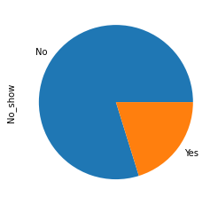

```python
df['No_show'].value_counts().plot(kind='pie');
df['No_show'].value_counts()
```

# Attendance to non-attendance rate is 79.81 % to 20.19 %.

```
Gender  No_show
F       No         57246
        Yes        14594
M       No         30962
        Yes         7725
Name: No_show, dtype: int64
```

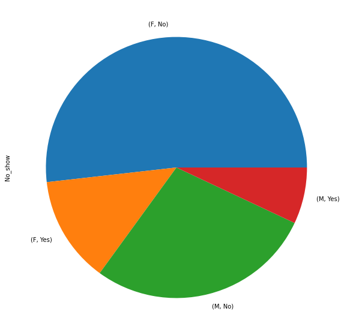

```python
df.groupby(['Gender','No_show']).No_show.count().plot(kind='pie',figsize=[10,10]);
df.groupby(['Gender','No_show']).No_show.count()
```

```
Alcoholism  Gender
0           F         70617
            M         36550
1           F          1223
            M          2137
Name: Age, dtype: int64
```

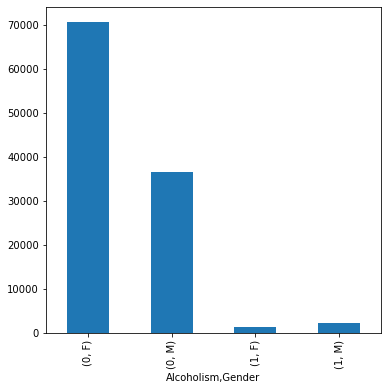

```python
df.groupby(['Alcoholism','Gender']).Age.count().plot(kind='bar',figsize=[6,6]);
df.groupby(['Alcoholism','Gender']).Age.count()
```

### Now we will view the relation between No_show and other variables:

### No Show cases according Age.

[output not shown]

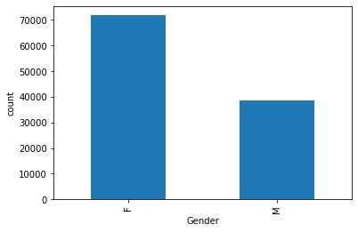

```python
df.groupby(['Gender'])['Age'].count().plot(kind='bar',ylabel='count');
df.groupby(['Gender'])['Age'].count()
```

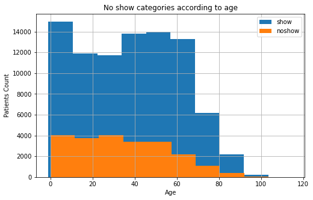

```python
plt.figure(figsize=[8,5])
df.Age[show].hist(label='show')
df.Age[noshow].hist(label='noshow')
plt.legend()
plt.title('No show categories according to age')
plt.xlabel('Age')
plt.ylabel('Patients Count');
```

### I will explain No show cases grouped by gender

```
Gender  No_show
F       No         57246
        Yes        14594
M       No         30962
        Yes         7725
Name: No_show, dtype: int64
```

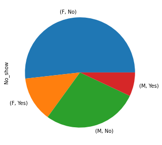

```python
df.groupby(['Gender','No_show']).No_show.count().plot(kind='pie',figsize=[5,5]);
df.groupby(['Gender','No_show']).No_show.count()
```

#### * As we see it is normal results,it did not show obvious reason to explain No_show cases.

#### * No significant correlation between No Show and Gender.

### No Show cases according Scheduled Day.

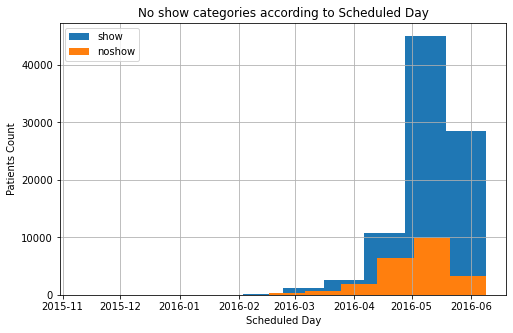

```python
plt.figure(figsize=[8,5])
df.Scheduled_Day[show].hist(label='show')
df.Scheduled_Day[noshow].hist(label='noshow')
plt.legend()
plt.title('No show categories according to Scheduled Day')
plt.xlabel('Scheduled Day')
plt.ylabel('Patients Count');
```

### No Show cases according Appointment Day.

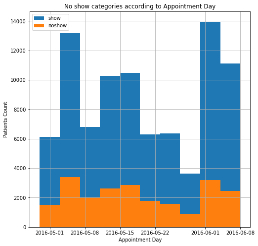

```python
plt.figure(figsize=[8,8])
df.Appointment_Day[show].hist(label='show')
df.Appointment_Day[noshow].hist(label='noshow')
plt.legend()
plt.title('No show categories according to Appointment Day')
plt.xlabel('Appointment Day')
plt.ylabel('Patients Count');
```

#### * As we see it is normal results,it did not show obvious reason to explain No_show cases.

#### * No significant correlation between No Show and Appointment day.

### No Show cases according Neighbourhood.

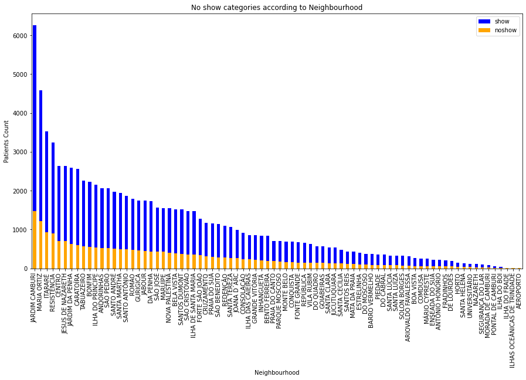

```python
plt.figure(figsize=[15,8])
df.Neighbourhood[show].value_counts().plot(kind='bar',color='blue',label='show')
df.Neighbourhood[noshow].value_counts().plot(kind='bar',color="orange",label='noshow')
plt.legend()
plt.title('No show categories according to Neighbourhood')
plt.xlabel('Neighbourhood')
plt.ylabel('Patients Count');
```

```python
df.groupby('Neighbourhood').No_show.value_counts()
```

```
Neighbourhood    No_show
AEROPORTO        No            7
                 Yes           1
ANDORINHAS       No         1741
                 Yes         521
ANTÔNIO HONÓRIO  No          221
                            ...
TABUAZEIRO       Yes         573
UNIVERSITÁRIO    No          120
                 Yes          32
VILA RUBIM       No          710
                 Yes         141
Name: No_show, Length: 160, dtype: int64
```

#### * As we see it is normal results,it did not show obvious reason to explain No_show cases.

#### * No significant correlation between No Show and Neighbourhood.

### No Show cases according Hypertension.

```
Hypertension  No_show
0             No         70179
              Yes        18547
1             No         18029
              Yes         3772
Name: No_show, dtype: int64
```

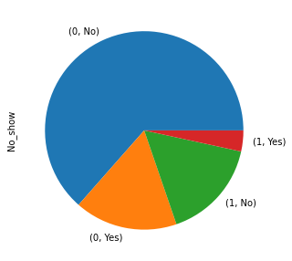

```python
df.groupby(['Hypertension','No_show']).No_show.count().plot(kind='pie',figsize=[5,5]);
df.groupby(['Hypertension','No_show']).No_show.count()
```

#### * As we see it is normal results,it did not show obvious reason to explain No_show cases.

#### * No significant correlation between No Show and Hypertension.

### No Show cases according Scholarship.

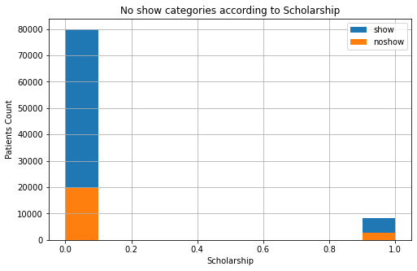

```python
plt.figure(figsize=[8,5])
df.Scholarship[show].hist(label='show')
df.Scholarship[noshow].hist(label='noshow')
plt.legend()
plt.title('No show categories according to Scholarship')
plt.xlabel('Scholarship')
plt.ylabel('Patients Count');
```

```python
df.groupby('Scholarship').No_show.value_counts()
```

```
Scholarship  No_show
0            No         79925
             Yes        19741
1            No          8283
             Yes         2578
Name: No_show, dtype: int64
```

#### * As we see it is normal results,it did not show obvious reason to explain No_show cases.

#### * No significant correlation between No Show and Scholarship.

### No Show cases according Diabetes.

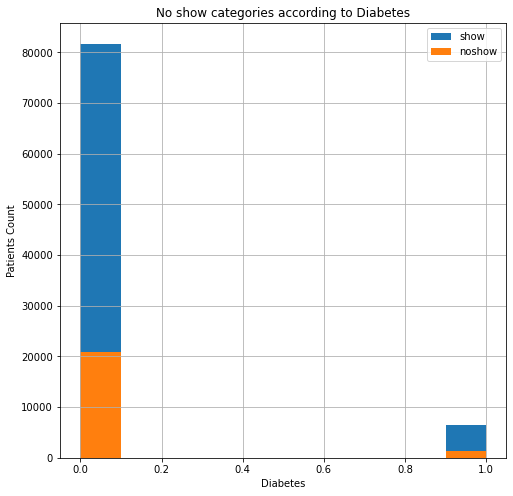

```python
plt.figure(figsize=[8,8])
df.Diabetes[show].hist(label='show')
df.Diabetes[noshow].hist(label='noshow')
plt.legend()
plt.title('No show categories according to Diabetes')
plt.xlabel('Diabetes')
plt.ylabel('Patients Count');
```

```python
df.groupby('Diabetes').No_show.value_counts()
```

```
Diabetes  No_show
0         No         81695
          Yes        20889
1         No          6513
          Yes         1430
Name: No_show, dtype: int64
```

#### * As we see it is normal results,it did not show obvious reason to explain No_show cases.

#### * No significant correlation between No Show and Diabetes.

### No Show cases according Alcoholism.

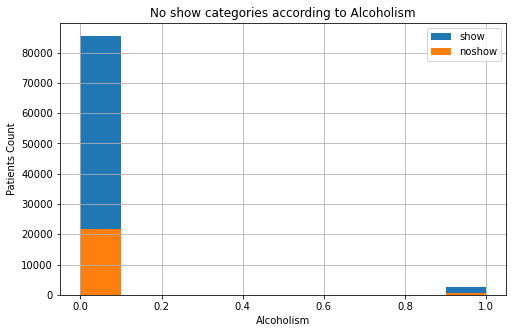

```python
plt.figure(figsize=[8,5])
df.Alcoholism[show].hist(label='show')
df.Alcoholism[noshow].hist(label='noshow')
plt.legend()
plt.title('No show categories according to Alcoholism')
plt.xlabel('Alcoholism')
plt.ylabel('Patients Count');
```

```python
df.groupby('Alcoholism').No_show.value_counts()
```

```
Alcoholism  No_show
0           No         85525
            Yes        21642
1           No          2683
            Yes          677
Name: No_show, dtype: int64
```

#### * As we see it is normal results,it did not show obvious reason to explain No_show cases.

#### * No significant correlation between No Show and Alcoholism.

### No Show cases according SMS_received.

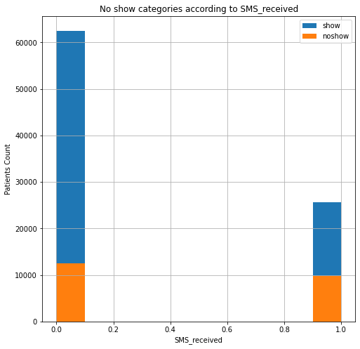

```python
plt.figure(figsize=[8,8])
df.SMS_received[show].hist(label='show')
df.SMS_received[noshow].hist(label='noshow')
plt.legend()
plt.title('No show categories according to SMS_received')
plt.xlabel('SMS_received')
plt.ylabel('Patients Count');
```

```python
df.groupby(['SMS_received','No_show']).count()
```

| SMS_received | No_show | Gender | Scheduled_Day | Appointment_Day | Age | Neighbourhood | Scholarship | Hypertension | Diabetes | Alcoholism | Handcap | Day_of_Schedule | Day_of_Appointment |
| --- | --- | --- | --- | --- | --- | --- | --- | --- | --- | --- | --- | --- | --- |
| 0 | No | 62510 | 62510 | 62510 | 62510 | 62510 | 62510 | 62510 | 62510 | 62510 | 62510 | 62510 | 62510 |
|  | Yes | 12535 | 12535 | 12535 | 12535 | 12535 | 12535 | 12535 | 12535 | 12535 | 12535 | 12535 | 12535 |
| 1 | No | 25698 | 25698 | 25698 | 25698 | 25698 | 25698 | 25698 | 25698 | 25698 | 25698 | 25698 | 25698 |
|  | Yes | 9784 | 9784 | 9784 | 9784 | 9784 | 9784 | 9784 | 9784 | 9784 | 9784 | 9784 | 9784 |

### No Show cases according Handcap.

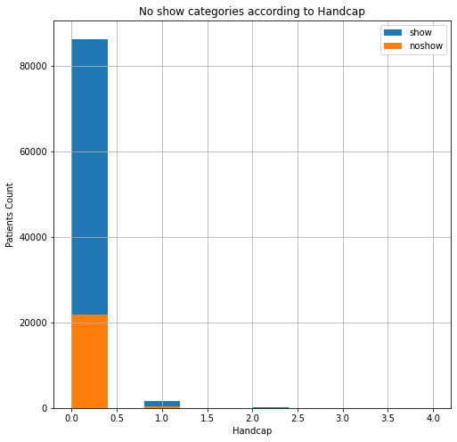

```python
plt.figure(figsize=[8,8])
df.Handcap[show].hist(label='show')
df.Handcap[noshow].hist(label='noshow')
plt.legend()
plt.title('No show categories according to Handcap')
plt.xlabel('Handcap')
plt.ylabel('Patients Count');
```

```python
df.groupby('Handcap').No_show.value_counts()
```

```
Handcap  No_show
0        No         86374
         Yes        21912
1        No          1676
         Yes          366
2        No           146
         Yes           37
3        No            10
         Yes            3
4        No             2
         Yes            1
Name: No_show, dtype: int64
```

#### * As we see it is normal results,it did not show obvious reason to explain No_show cases.

#### * No significant correlation between No Show and Handcap.

### No Show cases according Day of Schedule.

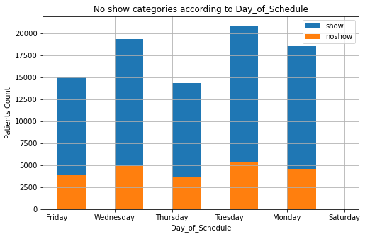

```python
plt.figure(figsize=[8,5])
df.Day_of_Schedule[show].hist(label='show')
df.Day_of_Schedule[noshow].hist(label='noshow')
plt.legend()
plt.title('No show categories according to Day_of_Schedule')
plt.xlabel('Day_of_Schedule')
plt.ylabel('Patients Count');
```

```python
df.groupby('Day_of_Schedule').No_show.value_counts()
```

```
Day_of_Schedule  No_show
Friday           No         15028
                 Yes         3887
Monday           No         18524
                 Yes         4561
Saturday         No            23
                 Yes            1
Thursday         No         14373
                 Yes         3700
Tuesday          No         20877
                 Yes         5291
Wednesday        No         19383
                 Yes         4879
Name: No_show, dtype: int64
```

#### * As we see it is normal results,it did not show obvious reason to explain No_show cases.

#### * No significant correlation between No Show and Day_of_Schedule.

### No Show cases according Day of Appointment.

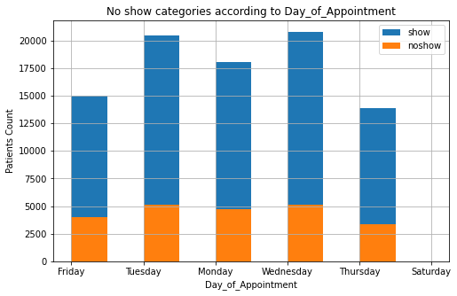

```python
plt.figure(figsize=[8,5])
df.Day_of_Appointment[show].hist(label='show')
df.Day_of_Appointment[noshow].hist(label='noshow')
plt.legend()
plt.title('No show categories according to Day_of_Appointment')
plt.xlabel('Day_of_Appointment')
plt.ylabel('Patients Count');
```

### I show below the count of go show patients nad no show according to day of week.

```python
df.groupby('Day_of_Appointment').No_show.value_counts()
```

```
Day_of_Appointment  No_show
Friday              No         14982
                    Yes         4037
Monday              No         18025
                    Yes         4690
Saturday            No            30
                    Yes            9
Thursday            No         13909
                    Yes         3338
Tuesday             No         20488
                    Yes         5152
Wednesday           No         20774
                    Yes         5093
Name: No_show, dtype: int64
```

## Attendance to non-attendance rate is 79.81 % to 20.19 %.

#### there is an entry is incorrect that Age value is -1.

### * notes:

#### This is what was shown to us through these variables, and it can be proven otherwise from the point of view of another study.

### Resources:

A list of Web sites:

1. http://pandas.pydata.org
2. https://stackoverflow.com
3. https://www.geeksforgeeks.org